# Final Project

Jzushi

4/16/2019

# Seagrass-associated Fungal Communities and Distributions

### Marine fungal biodiversity remains vastly understudied, even less is known of their biogeography and the processes responsible for driving these distributions in marine environments. Here we investigate the fungal communities associated with the seagrass Enhalus acoroides collected from Singapore and Peninsular Malaysia, to test the hypothesis that fungal communities are homogeneous throughout the study area. By doing so we also increase our knowledge of marine fungal diversity in an understudied region of the world.

### The samples that were collected from Singapore and Penisular Malaysia were sequenced and analyzed. Analysis of the data was done using three different scripts to:

### 1. Clean up the data

Script 01_raw_data_to_taxonomy.R loads the packages and the data which was then cleaned, filted, and trimmed using dada2, in order to assign it to a taxonomy and save it as an RDS file

### 2. Format the data into a phyloseq object to prepare for analysis

Script 02_creating_phyloseq.R loads packages and the RDS file that was created form the first script to further clean the data, create it into a phyloseq object, and save it as an RDS file

### 3. Analyze the data and create visual objects to intrepret the information.

Script 03_analyzing_phyloseq.R loads packages and the RDS file we created from the phyloseq object in the previous script to analyze our data and create graphs

## Loaded and explored the data to visualize the richness of the samples

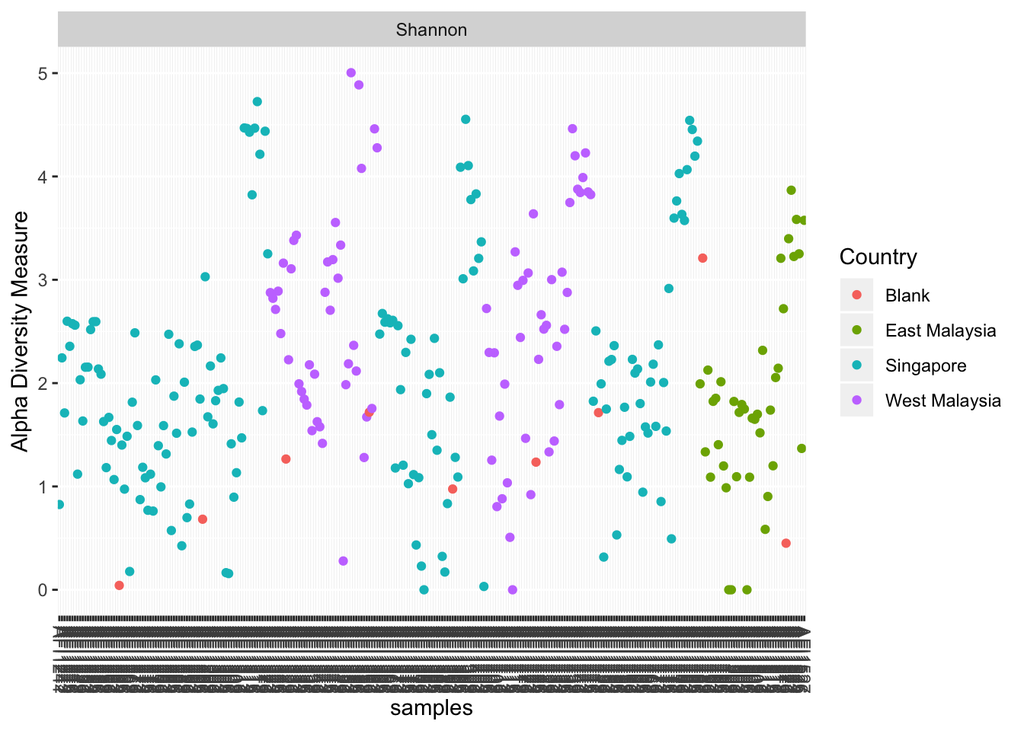

```r
plot_richness(ps,measures="Shannon",color="Country")
```

Cleaned our data a bit more by removing blanks and subsetting to only be from the fungi kingdom

## Network plotting

Plotted a network using a jaccard method with a max distance of 0.85

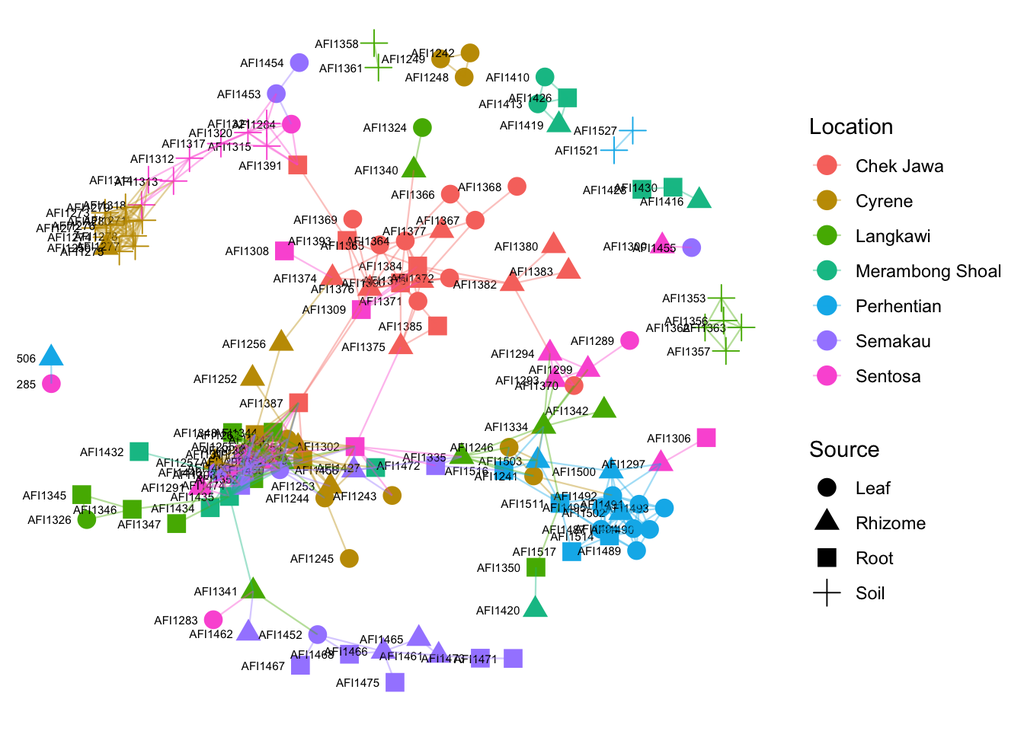

```r
plot_network(ig, physeq = GP, color = "Location", shape = "Source", line_weight = 0.4)
```

# Using top 100

Plotted the network of the top 100 taxa samples

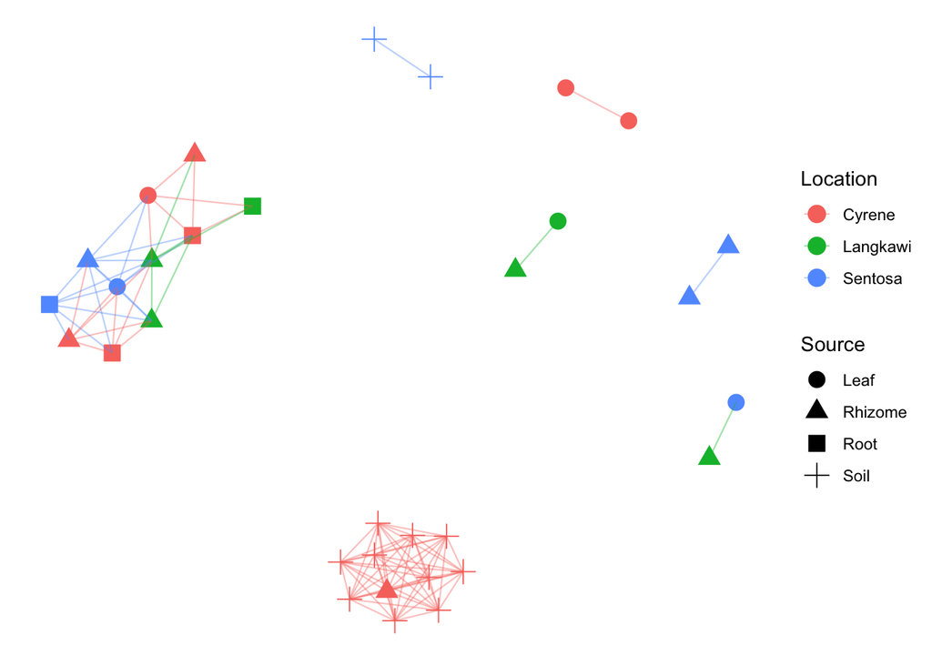

```r
plot_network(jg, physeq = GP100, color = "Location", shape = "Source", line_weight = 0.4, label = NULL)
```

## Principal Components Analysis

Ran an analysis to produce an ordination plot with limits being -10,10

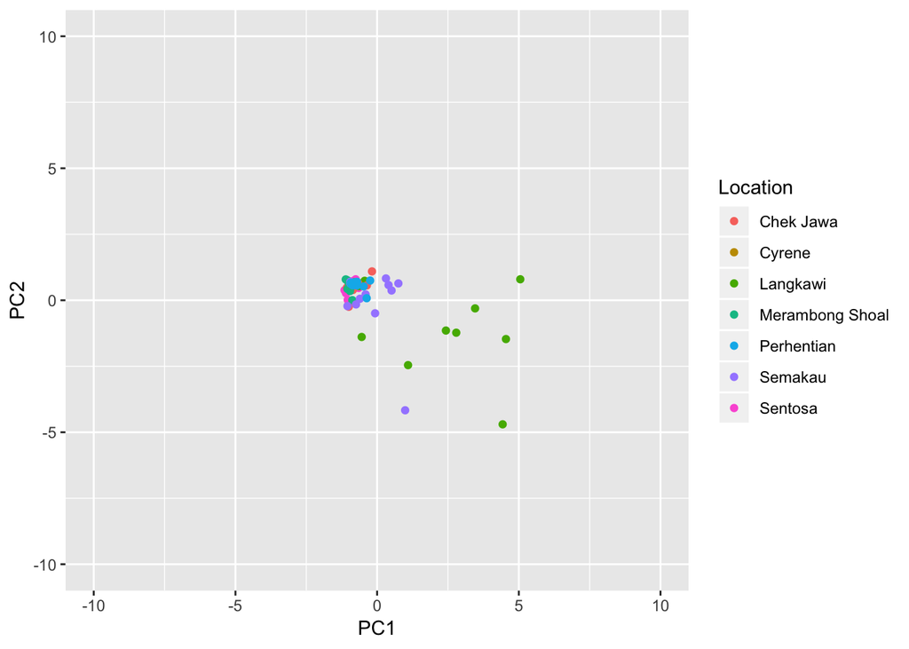

```r
plot_ordination(GP, pc, color= "Location") + lims(x=c(-10,10),y=c(-10,10))
```

## Merged by source and location

Repaired the values of source and location, removed the samples with nothing in it, and converted it to relative abundance to edit the taxon names to the correct format.

## Bar plot

Created a bar plot showing the location and class as a function of sample source.

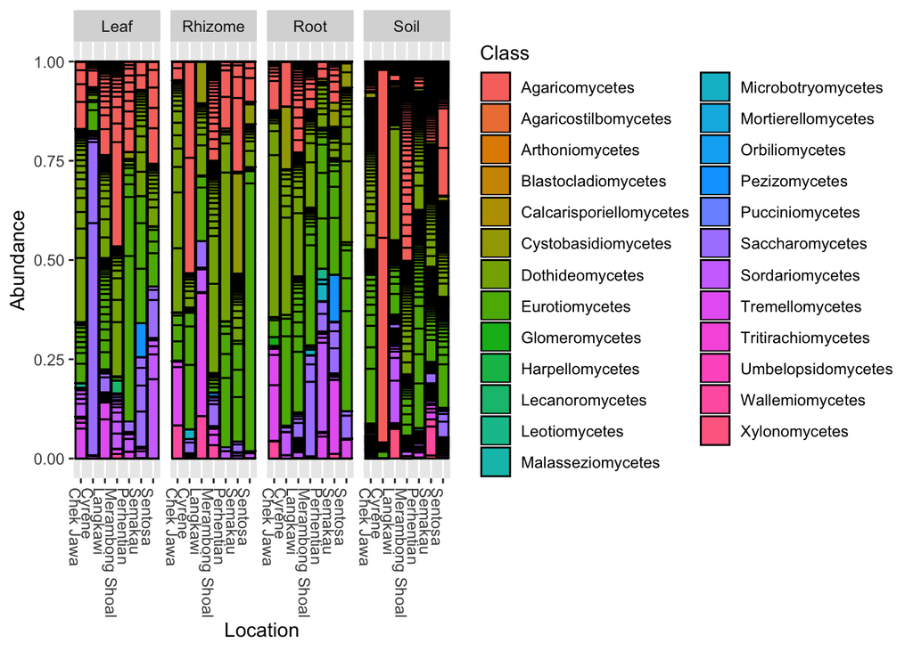

```r
plot_bar(GP.M, fill = "Class", x= "Location") + facet_grid(~Source)
```